# 2. Data Transformation

## 2.1 Data Loading

Export and import created to allow for loading of combined locational data. This is done so that the above chunk does not need to be run again

```r
#Import combined locational data
tweets_za <- read_rds("Data/Final_Data/tweets_za.rds")
tweets_bloem <- read_rds("Data/Final_Data/tweets_bloem.rds")
tweets_cpt <- read_rds("Data/Final_Data/tweets_cpt.rds")
tweets_durb <- read_rds("Data/Final_Data/tweets_durb.rds")
tweets_jhb <- read_rds("Data/Final_Data/tweets_jhb.rds")
tweets_kim <- read_rds("Data/Final_Data/tweets_kim.rds")
tweets_klerk <- read_rds("Data/Final_Data/tweets_klerk.rds")
tweets_mbomb <- read_rds("Data/Final_Data/tweets_mbomb.rds")
tweets_polo <- read_rds("Data/Final_Data/tweets_polo.rds")
tweets_pe <- read_rds("Data/Final_Data/tweets_pe.rds")
```

```r
#Load timeline data
News24_tweets <- read_rds("Data/Raw_Timeline_Data/News24_tweets.rds")
TimesLIVE_tweets <- read_rds("Data/Raw_Timeline_Data/TimesLIVE_tweets.rds")
eNCA_tweets <- read_rds("Data/Raw_Timeline_Data/eNCA_tweets.rds")
IOL_tweets <- read_rds("Data/Raw_Timeline_Data/IOL_tweets.rds")
SABCNews_tweets <- read_rds("Data/Raw_Timeline_Data/SABCNews_tweets.rds")
ewnupdates_tweets <- read_rds("Data/Raw_Timeline_Data/ewnupdates_tweets.rds")
```

## 2.2 Cleaning data

### Initial Data Clean

```r
#Separate date column & remove columns not used
News24_tweets <- separate(News24_tweets, created_at, into=c("date","time"), sep=" ") %>% mutate(date = as.Date(date)) %>% select(date, time, text, source, favorite_count, retweet_count)
TimesLIVE_tweets <- separate(TimesLIVE_tweets, created_at, into=c("date","time"), sep=" ") %>% mutate(date = as.Date(date)) %>% select(date, time, text, source, favorite_count, retweet_count)
ewnupdates_tweets <- separate(ewnupdates_tweets, created_at, into=c("date","time"), sep=" ") %>% mutate(date = as.Date(date)) %>% select(date, time, text, source, favorite_count, retweet_count)
IOL_tweets <- separate(IOL_tweets, created_at, into=c("date","time"), sep=" ") %>% mutate(date = as.Date(date)) %>% select(date, time, text, source, favorite_count, retweet_count)
eNCA_tweets <- separate(eNCA_tweets, created_at, into=c("date","time"), sep=" ") %>% mutate(date = as.Date(date)) %>% select(date, time, text, source, favorite_count, retweet_count)
SABCNews_tweets <- separate(SABCNews_tweets, created_at, into=c("date","time"), sep=" ") %>% mutate(date = as.Date(date)) %>% select(date, time, text, source, favorite_count, retweet_count)


#Subset data into 3 week range 1 June - 21 June
myfuncNews24 <- function(x,y){News24_tweets[News24_tweets$date >= x & News24_tweets$date <= y,]}
myfunctimesLIVE <- function(x,y){TimesLIVE_tweets[TimesLIVE_tweets$date >= x & TimesLIVE_tweets$date <= y,]}
myfuncEwnupdate <- function(x,y){ewnupdates_tweets[ewnupdates_tweets$date >= x & ewnupdates_tweets$date <= y,]}
myfuncIOL <- function(x,y){IOL_tweets[IOL_tweets$date >= x & IOL_tweets$date <= y,]}
myfunceNCA <- function(x,y){eNCA_tweets[eNCA_tweets$date >= x & eNCA_tweets$date <= y,]}
myfuncSABC <- function(x,y){SABCNews_tweets[SABCNews_tweets$date >= x & SABCNews_tweets$date <= y,]}

DATE1 <- as.Date("2020-06-01")
DATE2 <- as.Date("2020-06-21")

News24_tweets <- myfuncNews24(DATE1,DATE2)
TimesLIVE_tweets <- myfunctimesLIVE(DATE1,DATE2)
ewnupdates_tweets <- myfuncEwnupdate(DATE1,DATE2)
IOL_tweets <- myfuncIOL(DATE1,DATE2)
eNCA_tweets <- myfunceNCA(DATE1,DATE2)
SABCNews_tweets <- myfuncSABC(DATE1,DATE2)
```

### Text Cleaning Function

```r
data_cleaning <- function(x){

x <- x %>% select(text)
x <- unique(x)
x$text <- iconv(x$text,"UTF-8", "ASCII", sub="")#to remove emoji's
x$stripped_text <- tolower(x$text)
x$stripped_text <- gsub("http[^[:space:]]*", " ", x$stripped_text) # remove links
x$stripped_text <- gsub("@\\S*","", x$stripped_text) # remove mentions
x$stripped_text <- gsub("amp","", x$stripped_text)
x$stripped_text <- gsub("[\r\n]","", x$stripped_text)
x$stripped_text <- gsub("[[:punct:]]"," ", x$stripped_text) #remove punctuation
x$stripped_text = gsub("[ |\t]{2,}", " ", x$stripped_text) # remove tabs
x$stripped_text = gsub("^ ", "", x$stripped_text) # leading blanks
x$stripped_text = gsub(" $", "", x$stripped_text) #lagging blanks
x$stripped_text = gsub(" +", " ", x$stripped_text) #general spaces
x <- x %>% select(stripped_text)

}
```

### Final Cleaning

```r
#News Agency cleaning
tweets.News24_clean <- data_cleaning(News24_tweets)
tweets.TimesLIVE_clean <- data_cleaning(TimesLIVE_tweets)
tweets.eNCA_clean <- data_cleaning(eNCA_tweets)
tweets.IOL_clean <- data_cleaning(IOL_tweets)
tweets.ewn_clean <- data_cleaning(ewnupdates_tweets)
tweets.SABCNews_clean <- data_cleaning(SABCNews_tweets)


#Filter to selected Coronavirus related topics
tweets.News24_sub_clean <- tweets.News24_clean[grep("covid|corona|covid 19|covid19|coronavirus|sars cov 2|sars cov",tweets.News24_clean$stripped_text),]
tweets.TimesLIVE_sub_clean <- tweets.TimesLIVE_clean[grep("covid|corona|covid 19|covid19|coronavirus|sars cov 2|sars cov",tweets.TimesLIVE_clean$stripped_text),]
tweets.eNCA_sub_clean <- tweets.eNCA_clean[grep("covid|corona|covid 19|covid19|coronavirus|sars cov 2|sars cov",tweets.eNCA_clean$stripped_text),]
tweets.IOL_sub_clean <- tweets.IOL_clean[grep("covid|corona|covid 19|covid19|coronavirus|sars cov 2|sars cov",tweets.IOL_clean$stripped_text),]
tweets.ewn_sub_clean <- tweets.ewn_clean[grep("covid|corona|covid 19|covid19|coronavirus|sars cov 2|sars cov",tweets.ewn_clean$stripped_text),]
tweets.SABCNews_sub_clean <- tweets.SABCNews_clean[grep("covid|corona|covid 19|covid19|coronavirus|sars cov 2|sars cov",tweets.SABCNews_clean$stripped_text),]


#Preparation for Sentiment Analysis - Tokenize & Stem
tweets.News24_stem <- tweets.News24_sub_clean %>% unnest_tokens(word, stripped_text)
clean_tweets.News24 <- tweets.News24_stem %>% anti_join(stop_words)

tweets.TimesLIVE_stem <- tweets.TimesLIVE_sub_clean  %>% unnest_tokens(word, stripped_text)
clean_tweets.TimesLIVE <- tweets.TimesLIVE_stem %>% anti_join(stop_words)

tweets.eNCA_stem <- tweets.eNCA_sub_clean %>% unnest_tokens(word, stripped_text)
clean_tweets.eNCA <- tweets.eNCA_stem %>% anti_join(stop_words)

tweets.IOL_stem <- tweets.IOL_sub_clean %>% unnest_tokens(word, stripped_text)
clean_tweets.IOL <- tweets.IOL_stem %>% anti_join(stop_words)

tweets.ewn_stem <- tweets.ewn_sub_clean  %>% unnest_tokens(word, stripped_text)
clean_tweets.ewn <- tweets.ewn_stem %>% anti_join(stop_words)

tweets.SABCNews_stem <- tweets.SABCNews_sub_clean %>% unnest_tokens(word, stripped_text)
clean_tweets.SABCNews <- tweets.SABCNews_stem  %>% anti_join(stop_words)
```

```r
#Data across all media agencies
#Combined from cleaned versions of datasets
global_cleaned <- rbind(tweets.SABCNews_clean,tweets.ewn_clean,tweets.IOL_clean,tweets.eNCA_clean,tweets.TimesLIVE_clean,tweets.News24_clean)

global_tweets = rbind(SABCNews_tweets,eNCA_tweets,IOL_tweets,ewnupdates_tweets,TimesLIVE_tweets,News24_tweets)

#Preparation for Sentiment Analysis - Tokenize & Stem
Clean_tweets.global <- global_cleaned %>% unnest_tokens(word, stripped_text)
Clean_tweets.global <- Clean_tweets.global  %>% anti_join(stop_words)
```

### Cleaning Output Example

```r
head(tweets.News24_clean)
```

| stripped_text |
| --- |
| surfers warned of sharks cruising coast off the garden route |
| fears booze sales ban will leave a bad hangover that outlasts covid 19 pandemic |
| please dont touch my hair girl 7 reads poem she wrote about being black |
| lockdown taxi strike mbalula pleads with industry this is not the time for war |
| cop allegedly kills girlfriend during argument shoots himself |
| must see ring of fire solar eclipse thrills skywatchers |

### Cleaning Output Example 2 - Tokenize & Anti-join

```r
head(Clean_tweets.global)
```

| word |
| --- |
| confirmed |
| covid19 |
| south |
| africa |
| confirmed |
| 97 |

## 2.3 Sentiment Analysis

Afinn was the chosen lexicon, due to its ability to show negativity and positivity through the range -5 to 5.

```r
# Global
afinn_global <- Clean_tweets.global %>% inner_join(get_sentiments("afinn")) %>% count(word, value, sort = TRUE) %>% ungroup()

global_score <- afinn_global %>% group_by(value) %>% summarise(count = sum(n))

# News24
afinn_news24 <- clean_tweets.News24 %>% inner_join(get_sentiments("afinn")) %>% count(word, value, sort = TRUE) %>% ungroup()

news24_score <- afinn_news24 %>% group_by(value) %>% summarise(count = sum(n))

# TimesLIVE
afinn_TimesLIVE <- clean_tweets.TimesLIVE %>% inner_join(get_sentiments("afinn")) %>% count(word, value, sort = TRUE) %>% ungroup()

TimesLIVE_score <- afinn_TimesLIVE %>% group_by(value) %>% summarise(count = sum(n))

# eNCA
afinn_eNCA <- clean_tweets.eNCA %>% inner_join(get_sentiments("afinn")) %>% count(word, value, sort = TRUE) %>% ungroup()

eNCA_score <- afinn_eNCA %>% group_by(value) %>% summarise(count = sum(n))

# IOL
afinn_IOL <- clean_tweets.IOL %>% inner_join(get_sentiments("afinn")) %>% count(word, value, sort = TRUE) %>% ungroup()

IOL_score <- afinn_IOL %>% group_by(value) %>% summarise(count = sum(n))

# ewnupdate
afinn_ewn <- clean_tweets.ewn %>% inner_join(get_sentiments("afinn")) %>% count(word, value, sort = TRUE) %>% ungroup()

ewn_score <- afinn_ewn %>% group_by(value) %>% summarise(count = sum(n))

# SABCNEWS
afinn_SABCNews <- clean_tweets.SABCNews %>% inner_join(get_sentiments("afinn")) %>% count(word, value, sort = TRUE) %>% ungroup()

SABC_score <- afinn_SABCNews %>% group_by(value) %>% summarise(count = sum(n))
```

Example of resultant data for News24 seen in output

```r
head(news24_score)
```

| value | count |
| --- | --- |
| -4 | 2 |
| -3 | 83 |
| -2 | 156 |
| -1 | 119 |
| 1 | 61 |
| 2 | 123 |

## 2.4 Topic Modeliing

### Data Preparation

```r
#News24
News24_docs <- out_News24$documents
News24_vocab <- out_News24$vocab
News24_meta <-out_News24$meta

#TimesLIVE
TimesLIVE_docs <- out_TimesLIVE$documents
TimesLIVE_vocab <- out_TimesLIVE$vocab
TimesLIVE_meta <-out_TimesLIVE$meta

#EWN
ewn_docs <- out_ewn$documents
ewn_vocab <- out_ewn$vocab
ewn_meta <-out_ewn$meta

#IOL
IOL_docs <- out_IOL$documents
IOL_vocab <- out_IOL$vocab
IOL_meta <-out_IOL$meta

#eNCA
eNCA_docs <- out_eNCA$documents
eNCA_vocab <- out_eNCA$vocab
eNCA_meta <-out_eNCA$meta

#SABC
SABC_docs <- out_SABC$documents
SABC_vocab <- out_SABC$vocab
SABC_meta <-out_SABC$meta

#Global
global_docs <- out_global$documents
global_vocab <- out_global$vocab
global_meta <-out_global$meta
```

### Find Best K value

Upon visual inspection of the graphs produced. A K value of 16 was chosen and applied throughout.

```r
#NO RUN
global_findingk <- searchK(documents = global_docs, vocab = global_vocab, K = c(5:50),
 prevalence =~ date, data = global_meta, verbose=FALSE)
```

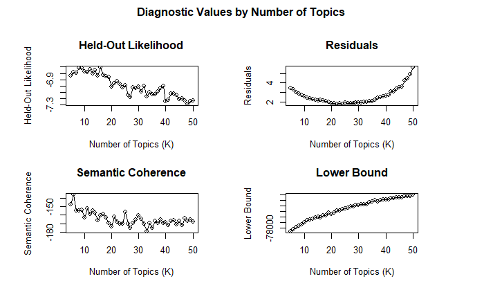

```r
global_findingk <- read_rds("Data/Final_Data/global_findingk.rds")
#write_rds(global_findingk, "Data/Final_Data/global_findingk.rds")
plot(global_findingk)
```

### Running STM Model

```r
#Running STM per news agency

News24_STM <- stm(documents = News24_docs, vocab = News24_vocab,
              K = 16, max.em.its = 75, data = News24_meta,
              init.type = "Spectral", verbose = FALSE)

timesLIVE_STM <- stm(documents = TimesLIVE_docs, vocab = TimesLIVE_vocab,
              K = 16, max.em.its = 75, data = TimesLIVE_meta,
              init.type = "Spectral", verbose = FALSE)

Ewnupdate_STM <- stm(documents = ewn_docs, vocab = ewn_vocab,
              K = 16, max.em.its = 75, data = ewn_meta,
              init.type = "Spectral", verbose = FALSE)

IOL_STM <- stm(documents = IOL_docs, vocab = IOL_vocab,
              K = 16, max.em.its = 75, data = IOL_meta,
              init.type = "Spectral", verbose = FALSE)

eNCA_STM <- stm(documents = eNCA_docs, vocab = eNCA_vocab,
              K = 16, max.em.its = 75, data = eNCA_meta,
              init.type = "Spectral", verbose = FALSE)

SABC_STM <- stm(documents = SABC_docs, vocab = SABC_vocab,
              K = 16, max.em.its = 75, data = SABC_meta,
              init.type = "Spectral", verbose = FALSE)

global_STM <- stm(documents = global_docs, vocab = global_vocab,
              K = 16, max.em.its = 75, data = global_meta,
              init.type = "Spectral", verbose = FALSE)
```

### Final tidying of data

```r
News24_topics <- tidy(News24_STM, matrix = "beta")
timesLIVE_topics <- tidy(timesLIVE_STM, matrix = "beta")
Ewnupdate_topics <- tidy(Ewnupdate_STM, matrix = "beta")
IOL_topics <- tidy(IOL_STM, matrix = "beta")
eNCA_topics <- tidy(eNCA_STM, matrix = "beta")
SABC_topics <- tidy(SABC_STM, matrix = "beta")
global_topics <- tidy(global_STM, matrix = "beta")

News24_top_terms <-
  News24_topics %>%
  group_by(topic) %>%
  top_n(5, beta) %>%
  ungroup() %>%
  arrange(topic, -beta)

timesLIVE_top_terms <-
  timesLIVE_topics %>%
  group_by(topic) %>%
  top_n(5, beta) %>%
  ungroup() %>%
  arrange(topic, -beta)

Ewnupdate_top_terms <-
  Ewnupdate_topics %>%
  group_by(topic) %>%
  top_n(5, beta) %>%
  ungroup() %>%
  arrange(topic, -beta)

IOL_top_terms <-
  IOL_topics %>%
  group_by(topic) %>%
  top_n(5, beta) %>%
  ungroup() %>%
  arrange(topic, -beta)

eNCA_top_terms <-
  eNCA_topics %>%
  group_by(topic) %>%
  top_n(5, beta) %>%
  ungroup() %>%
  arrange(topic, -beta)

SABC_top_terms <-
  SABC_topics %>%
  group_by(topic) %>%
  top_n(5, beta) %>%
  ungroup() %>%
  arrange(topic, -beta)

global_top_terms <-
  global_topics %>%
  group_by(topic) %>%
  top_n(5, beta) %>%
  ungroup() %>%
  arrange(topic, -beta)
```

### Example of output

```r
head(global_top_terms)
```

| topic | term | beta |
| --- | --- | --- |
| 1 | sabcnew | 0.11724853 |
| 1 | live | 0.04376813 |
| 1 | court | 0.03791029 |
| 1 | covid | 0.02631355 |
| 1 | media | 0.02117520 |
| 2 | coronavirus | 0.05778349 |

### 2.4.2 Latent Dirichlet Allocation Topic Modelling

LDA is a generative model and is able to generalize the model it uses to separate documents into topics to documents outside the corpora. LDA represents documents as random mixtures over topics in the corpus. This proves useful since any work of writing is rarely about a single subject.Therefore, LDA was also chosen for topic modelling.

### Create corpus datatypes

```r
corpusNews24 <- Corpus(VectorSource(tweets.News24_clean))
corpusNews24 <- tm_map(corpusNews24, removeWords, stopwords("english"))
corpusNews24 <- tm_map(corpusNews24, removeNumbers)
corpusNews24 <- tm_map(corpusNews24, stemDocument)
dtmNews24 = DocumentTermMatrix(corpusNews24)

corpusTimesLIVE <- Corpus(VectorSource(tweets.TimesLIVE_clean))
corpusTimesLIVE <- tm_map(corpusTimesLIVE, removeWords, stopwords("english"))
corpusTimesLIVE <- tm_map(corpusTimesLIVE, removeNumbers)
corpusTimesLIVE <- tm_map(corpusTimesLIVE, stemDocument)
dtmTimesLIVE = DocumentTermMatrix(corpusTimesLIVE)

corpuseNCA <- Corpus(VectorSource(tweets.eNCA_clean))
corpuseNCA <- tm_map(corpuseNCA, removeWords, stopwords("english"))
corpuseNCA <- tm_map(corpuseNCA, removeNumbers)
corpuseNCA <- tm_map(corpuseNCA, stemDocument)
dtmeNCA = DocumentTermMatrix(corpuseNCA)

corpusIOL <- Corpus(VectorSource(tweets.IOL_clean))
corpusIOL <- tm_map(corpusIOL, removeWords, stopwords("english"))
corpusIOL <- tm_map(corpusIOL, removeNumbers)
corpusIOL <- tm_map(corpusIOL, stemDocument)
dtmIOL = DocumentTermMatrix(corpusIOL)

corpusewn <- Corpus(VectorSource(tweets.ewn_clean))
corpusewn <- tm_map(corpusewn, removeWords, stopwords("english"))
corpusewn <- tm_map(corpusewn, removeNumbers)
corpusewn <- tm_map(corpusewn, stemDocument)
dtmewn = DocumentTermMatrix(corpusewn)

corpusSABCNews <- Corpus(VectorSource(tweets.SABCNews_clean))
corpusSABCNews <- tm_map(corpusSABCNews, removeWords, stopwords("english"))
corpusSABCNews <- tm_map(corpusSABCNews, removeNumbers)
corpusSABCNews <- tm_map(corpusSABCNews, stemDocument)
dtmSABCNews = DocumentTermMatrix(corpusSABCNews)

corpusGlobal <- Corpus(VectorSource(global_cleaned))
corpusGlobal <- tm_map(corpusGlobal, removeWords, stopwords("english"))
corpusGlobal <- tm_map(corpusGlobal, removeNumbers)
corpusGlobal <- tm_map(corpusGlobal, stemDocument)
dtmGlobal = DocumentTermMatrix(corpusGlobal)
```

### Running Latent Dirichlet Allocation Model

The Gibbs method was chosen as the LDA method. The Gibbs method produced more accurate topics, however it is important to note that the method introduced anomalies.

```r
#LDA model with 16 topics selected
News24_lda = LDA(dtmNews24, k = 16, method = 'Gibbs', control = list(nstart = 5, seed = list(1505,99,36,56,88), best = TRUE,thin = 500, burnin = 4000, iter = 2000))

#LDA model with 16 topics selected
TimesLIVE_lda = LDA(dtmTimesLIVE, k = 16, method = 'Gibbs', control = list(nstart = 5, seed = list(1505,99,36,56,88), best = TRUE,thin = 500, burnin = 4000, iter = 2000))

#LDA model with 16 topics selected
eNCA_lda = LDA(dtmeNCA, k = 16, method = 'Gibbs', control = list(nstart = 5, seed = list(1505,99,36,56,88), best = TRUE,thin = 500, burnin = 4000, iter = 2000))

#LDA model with 16 topics selected
IOL_lda = LDA(dtmIOL, k = 16, method = 'Gibbs', control = list(nstart = 5, seed = list(1505,99,36,56,88), best = TRUE,thin = 500, burnin = 4000, iter = 2000))

#LDA model with 16 topics selected
ewn_lda = LDA(dtmewn, k = 16, method = 'Gibbs', control = list(nstart = 5, seed = list(1505,99,36,56,88), best = TRUE,thin = 500, burnin = 4000, iter = 2000))

#LDA model with 16 topics selected
SABCNews_lda = LDA(dtmSABCNews, k = 16, method = 'Gibbs', control = list(nstart = 5, seed = list(1505,99,36,56,88), best = TRUE,thin = 500, burnin = 4000, iter = 2000))

#LDA model with 16 topics selected
Global_lda = LDA(dtmGlobal, k = 16, method = 'Gibbs', control = list(nstart = 5, seed = list(1505,99,36,56,88), best = TRUE,thin = 500, burnin = 4000, iter = 2000))
```

### Final tidying of data

```r
News24_topics_LDA <- tidy(News24_lda, matrix = "beta")
TimesLIVE_topics_LDA <- tidy(TimesLIVE_lda, matrix = "beta")
eNCA_topics_LDA <- tidy(eNCA_lda, matrix = "beta")
IOL_topics_LDA <- tidy(IOL_lda, matrix = "beta")
ewn_topics_LDA <- tidy(ewn_lda, matrix = "beta")
SABCNews_topics_LDA <- tidy(SABCNews_lda, matrix = "beta")
Global_topics_LDA <- tidy(Global_lda, matrix = "beta")

News24_top_terms_LDA <-
  News24_topics_LDA %>%
  group_by(topic) %>%
  top_n(5, beta) %>%
  ungroup() %>%
  arrange(topic, -beta)

d <- by(News24_top_terms_LDA, News24_top_terms_LDA["topic"], head, n=5)
News24_top_terms_LDA <- rbind(d[[1]],d[[2]],d[[3]],d[[4]],d[[5]],d[[6]],d[[7]],d[[8]],d[[9]],d[[10]],d[[11]],d[[12]],d[[13]],d[[14]],d[[15]],d[[16]])


TimesLIVE_top_terms_LDA <-
  TimesLIVE_topics_LDA %>%
  group_by(topic) %>%
  top_n(5, beta) %>%
  ungroup() %>%
  arrange(topic, -beta)

d <- by(TimesLIVE_top_terms_LDA, TimesLIVE_top_terms_LDA["topic"], head, n=5)
TimesLIVE_top_terms_LDA <- rbind(d[[1]],d[[2]],d[[3]],d[[4]],d[[5]],d[[6]],d[[7]],d[[8]],d[[9]],d[[10]],d[[11]],d[[12]],d[[13]],d[[14]],d[[15]],d[[16]])

eNCA_top_terms_LDA <-
  eNCA_topics_LDA %>%
  group_by(topic) %>%
  top_n(5, beta) %>%
  ungroup() %>%
  arrange(topic, -beta)

d <- by(eNCA_top_terms_LDA, eNCA_top_terms_LDA["topic"], head, n=5)
eNCA_top_terms_LDA <- rbind(d[[1]],d[[2]],d[[3]],d[[4]],d[[5]],d[[6]],d[[7]],d[[8]],d[[9]],d[[10]],d[[11]],d[[12]],d[[13]],d[[14]],d[[15]],d[[16]])

IOL_top_terms_LDA <-
  IOL_topics_LDA %>%
  group_by(topic) %>%
  top_n(5, beta) %>%
  ungroup() %>%
  arrange(topic, -beta)

d <- by(IOL_top_terms_LDA, IOL_top_terms_LDA["topic"], head, n=5)
IOL_top_terms_LDA <- rbind(d[[1]],d[[2]],d[[3]],d[[4]],d[[5]],d[[6]],d[[7]],d[[8]],d[[9]],d[[10]],d[[11]],d[[12]],d[[13]],d[[14]],d[[15]],d[[16]])

ewn_top_terms_LDA <-
  ewn_topics_LDA %>%
  group_by(topic) %>%
  top_n(5, beta) %>%
  ungroup() %>%
  arrange(topic, -beta)

d <- by(ewn_top_terms_LDA, ewn_top_terms_LDA["topic"], head, n=5)
ewn_top_terms_LDA <- rbind(d[[1]],d[[2]],d[[3]],d[[4]],d[[5]],d[[6]],d[[7]],d[[8]],d[[9]],d[[10]],d[[11]],d[[12]],d[[13]],d[[14]],d[[15]],d[[16]])

SABCNews_top_terms_LDA <-
  SABCNews_topics_LDA %>%
  group_by(topic) %>%
  top_n(5, beta) %>%
  ungroup() %>%
  arrange(topic, -beta)

d <- by(SABCNews_top_terms_LDA, SABCNews_top_terms_LDA["topic"], head, n=5)
SABCNews_top_terms_LDA <- rbind(d[[1]],d[[2]],d[[3]],d[[4]],d[[5]],d[[6]],d[[7]],d[[8]],d[[9]],d[[10]],d[[11]],d[[12]],d[[13]],d[[14]],d[[15]],d[[16]])

Global_top_terms_LDA <-
  Global_topics_LDA %>%
  group_by(topic) %>%
  top_n(5, beta) %>%
  ungroup() %>%
  arrange(topic, -beta)

d <- by(Global_top_terms_LDA, Global_top_terms_LDA["topic"], head, n=5)
Global_top_terms_LDA <- rbind(d[[1]],d[[2]],d[[3]],d[[4]],d[[5]],d[[6]],d[[7]],d[[8]],d[[9]],d[[10]],d[[11]],d[[12]],d[[13]],d[[14]],d[[15]],d[[16]])
```

### Example of output

```r
head(Global_top_terms_LDA)
```

| topic | term | beta |
| --- | --- | --- |
| 1 | scourg | 0.004304100 |
| 1 | ministri | 0.003451803 |
| 1 | "australia | 0.002173357 |
| 1 | "zimbabw | 0.002173357 |
| 1 | daughter", | 0.002173357 |
| 2 | "beij | 0.002206264 |

## 2.5 Additional Analysis

### Frequency of Tweets

```r
News24_freq <- News24_tweets %>% group_by(date) %>% summarise(News24 = n())
timesLIVE_freq <- TimesLIVE_tweets %>% group_by(date) %>% summarise(timesLIVE = n()) %>% select(timesLIVE)
Ewnupdate_freq <- ewnupdates_tweets %>% group_by(date) %>% summarise(Ewnupdate = n()) %>% select(Ewnupdate)
IOL_freq <- IOL_tweets %>% group_by(date) %>% summarise(IOL = n()) %>% select(IOL)
eNCA_freq <- eNCA_tweets %>% group_by(date) %>% summarise(eNCA = n()) %>% select(eNCA)
SABC_freq <- SABCNews_tweets %>% group_by(date) %>% summarise(SABC = n()) %>% select(SABC)

# sum days and join together
Frequency_tweets <- bind_cols(News24_freq,timesLIVE_freq,Ewnupdate_freq,IOL_freq,eNCA_freq,SABC_freq)
```

Example of output

```r
head(Frequency_tweets)
```

| date | News24 | timesLIVE | Ewnupdate | IOL | eNCA | SABC |
| --- | --- | --- | --- | --- | --- | --- |
| 2020-06-01 | 137 | 71 | 77 | 77 | 62 | 50 |
| 2020-06-02 | 91 | 90 | 82 | 67 | 52 | 50 |
| 2020-06-03 | 132 | 90 | 83 | 75 | 56 | 45 |
| 2020-06-04 | 116 | 84 | 85 | 84 | 64 | 34 |
| 2020-06-05 | 119 | 79 | 82 | 65 | 93 | 48 |
| 2020-06-06 | 97 | 42 | 32 | 53 | 23 | 64 |

### Retweet count

```r
News24_retweet <- News24_tweets %>% group_by(date) %>% summarise(News24 = sum(retweet_count))
timesLIVE_retweet <- TimesLIVE_tweets %>% group_by(date) %>% summarise(timesLIVE = sum(retweet_count)) %>% select(timesLIVE)
Ewnupdate_retweet <- ewnupdates_tweets %>% group_by(date) %>% summarise(Ewnupdate = sum(retweet_count)) %>% select(Ewnupdate)
IOL_retweet <- IOL_tweets %>% group_by(date) %>% summarise(IOL = sum(retweet_count)) %>% select(IOL)
eNCA_retweet <- eNCA_tweets %>% group_by(date) %>% summarise(eNCA = sum(retweet_count)) %>% select(eNCA)
SABC_retweet <- SABCNews_tweets %>% group_by(date) %>% summarise(SABC = sum(retweet_count)) %>% select(SABC)

# sum days and join together
retweet_tweets <- bind_cols(News24_retweet,timesLIVE_retweet,Ewnupdate_retweet,IOL_retweet,eNCA_retweet,SABC_retweet)
```

Example of output

```r
head(retweet_tweets)
```

| date | News24 | timesLIVE | Ewnupdate | IOL | eNCA | SABC |
| --- | --- | --- | --- | --- | --- | --- |
| 2020-06-01 | 2945 | 256 | 237 | 498 | 1424 | 444 |
| 2020-06-02 | 8595 | 548 | 1160 | 1116 | 1261 | 368 |
| 2020-06-03 | 3221 | 460 | 736 | 839 | 895 | 519 |
| 2020-06-04 | 8212 | 538 | 482 | 606 | 1234 | 818 |
| 2020-06-05 | 3064 | 455 | 518 | 669 | 1220 | 845 |
| 2020-06-06 | 1644 | 494 | 231 | 330 | 492 | 471 |

### Like count

```r
# like count
News24_likes <- News24_tweets %>% group_by(date) %>% summarise(News24 = sum(favorite_count))
timesLIVE_likes <- TimesLIVE_tweets %>% group_by(date) %>% summarise(timesLIVE = sum(favorite_count)) %>% select(timesLIVE)
Ewnupdate_likes <- ewnupdates_tweets %>% group_by(date) %>% summarise(Ewnupdate = sum(favorite_count)) %>% select(Ewnupdate)
IOL_likes <- IOL_tweets %>% group_by(date) %>% summarise(IOL = sum(favorite_count)) %>% select(IOL)
eNCA_likes <- eNCA_tweets %>% group_by(date) %>% summarise(eNCA = sum(favorite_count)) %>% select(eNCA)
SABC_likes <- SABCNews_tweets %>% group_by(date) %>% summarise(SABC = sum(favorite_count)) %>% select(SABC)

# sum days and join together
Likes_tweets <- bind_cols(News24_likes,timesLIVE_likes,Ewnupdate_likes,IOL_likes,eNCA_likes,SABC_likes)
```

```r
head(retweet_tweets)
```

[output not shown]

### Total number of tweets vs Covid tweets

```r
#count the total number of tweets vs covid tweets
News24_Genposts <- nrow(News24_tweets)
timesLIVE_Genposts <- nrow(TimesLIVE_tweets)
Ewnupdate_Genposts <- nrow(ewnupdates_tweets)
IOL_Genposts <- nrow(IOL_tweets)
eNCA_Genposts<- nrow(eNCA_tweets)
SABC_Genposts <- nrow(SABCNews_tweets)

News24_CVDposts <- nrow(tweets.News24_sub_clean)
timesLIVE_CVDposts <- nrow(tweets.TimesLIVE_sub_clean)
Ewnupdate_CVDposts <- nrow(tweets.ewn_sub_clean)
IOL_CVDposts <- nrow(tweets.IOL_sub_clean)
eNCA_CVDposts<- nrow(tweets.eNCA_sub_clean)
SABC_CVDposts <- nrow(tweets.SABCNews_sub_clean)

Gen_tweets <- News24_Genposts + timesLIVE_Genposts + Ewnupdate_Genposts + IOL_Genposts +eNCA_Genposts + SABC_Genposts

CVD_tweets <- News24_CVDposts + timesLIVE_CVDposts + Ewnupdate_CVDposts + IOL_CVDposts + eNCA_CVDposts + SABC_CVDposts

Other_tweets <- Gen_tweets - CVD_tweets

tweet_type <- c("General","Covid-related")
tweet_count <- c(Other_tweets,CVD_tweets)

Type_data <- data.frame(tweet_type,tweet_count)
```

Example of output

```r
head(Type_data)
```

|  | tweet_type | tweet_count |
| --- | --- | --- |
| 1 | General | 6890 |
| 2 | Covid-related | 2011 |

### General tweets RSA vs those belonging to selected news agencies

```r
Media_tweets <- tweets_za %>% filter(screen_name == "TimesLIVE" | screen_name == "IOL" | screen_name == "eNCA" | screen_name == "ewnupdates" | screen_name == "SABCNews" | screen_name == "News24") %>% nrow()

RSA_other_tweets <- nrow(tweets_za) - Media_tweets

RSA_tweeter <- c("Selected Media","Other")
RSA_tweet_value <- c(Media_tweets,RSA_other_tweets)

RSA_data <- data.frame(RSA_tweeter,RSA_tweet_value)
```

Example of output

```r
head(RSA_data)
```

|  | RSA_tweeter | RSA_tweet_value |
| --- | --- | --- |
| 1 | Selected Media | 1059 |
| 2 | Other | 61535 |

### Followers for selected news agency

```r
News24_followers <- tweets_za %>% filter(screen_name == "News24") %>% head(1) %>% select(followers_count)
TimesLIVE_followers <- tweets_za %>% filter(screen_name == "TimesLIVE") %>% head(1) %>% select(followers_count)
ewn_followers <- tweets_za %>% filter(screen_name == "ewnupdates") %>% head(1) %>% select(followers_count)
IOL_followers <- tweets_za %>% filter(screen_name == "IOL") %>% head(1) %>% select(followers_count)
eNCA_followers <- tweets_za %>% filter(screen_name == "eNCA") %>% head(1) %>% select(followers_count)
SABC_followers <- tweets_za %>% filter(screen_name == "SABCNews") %>% head(1) %>% select(followers_count)

Media <- c("News24","TimesLIVE","ewnupdates","IOL","eNCA","SABCNews")
Followers_media <- data.frame(Media,rbind(News24_followers,TimesLIVE_followers,ewn_followers,IOL_followers,eNCA_followers,SABC_followers))
```

Example of output

```r
head(Followers_media)
```

|  | Media | followers_count |
| --- | --- | --- |
| 1 | News24 | 3538912 |
| 2 | TimesLIVE | 1415815 |
| 3 | ewnupdates | 1150507 |
| 4 | IOL | 430750 |
| 5 | eNCA | 2370537 |
| 6 | SABCNews | 1629914 |

### Distribution and Percentage of total tweets across major cities

```r
bloem_nr <- nrow(tweets_bloem)
cpt_nr <- nrow(tweets_cpt)
durb_nr <- nrow(tweets_durb)
jhb_nr <- nrow(tweets_jhb)
kim_nr <- nrow(tweets_kim)
klerk_nr <- nrow(tweets_klerk)
mbomb_nr <- nrow(tweets_mbomb)
pe_nr <- nrow(tweets_pe)
polo_nr <- nrow(tweets_polo)


city_tweets <- rbind(bloem_nr,cpt_nr,durb_nr,kim_nr,jhb_nr,klerk_nr,mbomb_nr,pe_nr,polo_nr)
cityNames <- rbind("Bloem","CPT", "Durban", "Kimberley" ,"JHB", "Klerks", "Mbombela", "Polokwane", "P.E")

cityCombined <- data.frame(cityNames,city_tweets)
cityCombined <- cityCombined %>% add_column(Percentage = (city_tweets/(sum(city_tweets))) * 100)
```

Example of output

```r
head(cityCombined)
```

|  | cityNames | city_tweets | Percentage |
| --- | --- | --- | --- |
| bloem_nr | Bloem | 404 | 2.2446939 |
| cpt_nr | CPT | 5729 | 31.8313146 |
| durb_nr | Durban | 98 | 0.5445049 |
| kim_nr | Kimberley | 411 | 2.2835871 |
| jhb_nr | JHB | 10101 | 56.1229025 |
| klerk_nr | Klerks | 56 | 0.3111457 |

## 2.6 Data Export

```r
# Sentiment Analysis
write_rds(afinn_global, "Data/Final_Data/afinn_global.rds")
write_rds(global_score, "Data/Final_Data/global_score.rds")
write_rds(afinn_news24, "Data/Final_Data/afinn_news24.rds")
write_rds(news24_score, "Data/Final_Data/news24_score.rds")
write_rds(afinn_TimesLIVE, "Data/Final_Data/afinn_TimesLIVE.rds")
write_rds(TimesLIVE_score, "Data/Final_Data/TimesLIVE_score.rds")
write_rds(afinn_eNCA, "Data/Final_Data/afinn_eNCA.rds")
write_rds(eNCA_score, "Data/Final_Data/eNCA_score.rds")
write_rds(afinn_IOL, "Data/Final_Data/afinn_IOL.rds")
write_rds(IOL_score, "Data/Final_Data/IOL_score.rds")
write_rds(afinn_ewn, "Data/Final_Data/afinn_ewn.rds")
write_rds(ewn_score, "Data/Final_Data/ewn_score.rds")
write_rds(afinn_SABCNews, "Data/Final_Data/afinn_SABCNews.rds")
write_rds(SABC_score, "Data/Final_Data/SABC_score.rds")

#LDA
write_rds(News24_top_terms_LDA, "Data/Final_Data/News24_top_terms_LDA.rds")
write_rds(TimesLIVE_top_terms_LDA, "Data/Final_Data/timesLIVE_top_terms_LDA.rds")
write_rds(ewn_top_terms_LDA, "Data/Final_Data/Ewnupdate_top_terms_LDA.rds")
write_rds(IOL_top_terms_LDA, "Data/Final_Data/IOL_top_terms_LDA.rds")
write_rds(eNCA_top_terms_LDA, "Data/Final_Data/eNCA_top_terms_LDA.rds")
write_rds(SABCNews_top_terms_LDA, "Data/Final_Data/SABC_top_terms_LDA.rds")
write_rds(Global_top_terms_LDA, "Data/Final_Data/global_top_terms_LDA.rds")

#STM
write_rds(News24_top_terms, "Data/Final_Data/News24_top_terms.rds")
write_rds(timesLIVE_top_terms, "Data/Final_Data/timesLIVE_top_terms.rds")
write_rds(Ewnupdate_top_terms, "Data/Final_Data/Ewnupdate_top_terms.rds")
write_rds(IOL_top_terms, "Data/Final_Data/IOL_top_terms.rds")
write_rds(eNCA_top_terms, "Data/Final_Data/eNCA_top_terms.rds")
write_rds(SABC_top_terms, "Data/Final_Data/SABC_top_terms.rds")
write_rds(global_top_terms, "Data/Final_Data/global_top_terms.rds")

# Additional Analysis
write_rds(Frequency_tweets,"Data/Final_Data/Frequency_tweets.rds")
write_rds(retweet_tweets,"Data/Final_Data/retweet_tweets.rds")
write_rds(Likes_tweets,"Data/Final_Data/Like_tweets.rds")
write_rds(Type_data,"Data/Final_Data/Tweet_Type.rds")
write_rds(RSA_data,"Data/Final_Data/RSA_data.rds")
write_rds(Followers_media,"Data/Final_Data/Followers_media.rds")
write_rds(tweets_za,"Data/Final_Data/tweets_za.rds")
write_rds(cityCombined,"Data/Final_Data/cityCombined.rds")
```